[figure not shown]

# Determinants of a Mobile Strategy Game's Success

Anna Carandang, Jacqueline Gao, and Mahreen Haider

1. Introduction
2. Data Collection
3. Data Processing
4. Exploratory Analysis and Data Visualization
5. Analysis, Hypothesis Testing, and Machine Learning
6. Insight and Policy Decision

# 1. Introduction

The global mobile gaming market is thriving, with some of its most popular apps raking in billions of dollars in revenue. Some of these heavyweights include Clash of Clans, PUBG Mobile, Plants vs. Zombies, Pokemon Go, and Agari.io. Companies are investing vast amounts of money into the development of such games. However, in such a competitive and ever-growing market, it can be difficult for an app to prosper.

In this tutorial, we will examine numerous factors to see if they can be used as a predictor of a mobile strategy game's success. The dataset we will be using is the data of 17007 strategy games on the Apple App Store, collected from [Kaggle](https://www.kaggle.com/tristan581/17k-apple-app-store-strategy-games). For the purposes of this tutorial, we will associate success with the average user rating value.

# 2. Data Collection

This step of the data life cycle focuses on gathering data from different sources, such as websites or files. We start by importing the required tools and libraries. Additional information on how to upgrade from pip to pip3 and use it to install the required packages can be found [here](https://help.dreamhost.com/hc/en-us/articles/115000699011-Using-pip3-to-install-Python3-modules). We will use Python 3 for this data anaysis along with some libraries such as [pandas](https://pandas.pydata.org/pandas-docs/stable/),[numpy](https://docs.scipy.org/doc/numpy/user/),[scikit-learn](https://scikit-learn.org/stable/index.html),[matplotlib](https://matplotlib.org/contents.html), etc. We're using pip3 because it is used to install packages for Python 3, which is used in this tutorial.

Additional reading (2. Data Mining): https://towardsdatascience.com/data-science-life-cycle-101-for-dummies-like-me-e66b47ad8d8f

```python
# Imports required tools and libraries
from sklearn import linear_model
from sklearn import ensemble
from sklearn.svm import SVR, LinearSVR
from sklearn.neighbors import KNeighborsRegressor
from sklearn import model_selection
from sklearn import preprocessing
import matplotlib.pyplot as plt
import numpy as np
import pandas as pd
import seaborn as sns
```

## Dataset Source

Here, we utilize the [read_csv](https://pandas.pydata.org/pandas-docs/stable/reference/api/pandas.read_csv.html) function to read the CSV (comma-separated values) file obtained from [Kaggle](https://www.kaggle.com/tristan581/17k-apple-app-store-strategy-games). The dataset contains details about mobile games including factors like player age, price, average user ratings, languages, etc. We will place the data into a DataFrame called games for later processing and analysis. We print out the first few rows of the resulting DataFrame.

The dataset may be updated in the future, so if you're interested, you can obtain the version of the dataset that we have used [here](https://github.com/jacquelinegao/jacquelinegao.github.io/blob/master/appstore_games.csv).

Special thanks to tristan581 for providing us with the data!

```python
# Reads CSV file
games = pd.read_csv("appstore_games.csv")

# Prints first five rows of DataFrame
games.head()
```

|  | URL | ID | Name | Subtitle | Icon URL | Average User Rating | User Rating Count | Price | In-app Purchases | Description | Developer | Age Rating | Languages | Size | Primary Genre | Genres | Original Release Date | Current Version Release Date |
| --- | --- | --- | --- | --- | --- | --- | --- | --- | --- | --- | --- | --- | --- | --- | --- | --- | --- | --- |
| 0 | https://apps.apple.com/us/app/sudoku/id284921427 | 284921427 | Sudoku | NaN | https://is2-ssl.mzstatic.com/image/thumb/Purpl... | 4.0 | 3553.0 | 2.99 | NaN | Join over 21,000,000 of our fans and download ... | Mighty Mighty Good Games | 4+ | DA, NL, EN, FI, FR, DE, IT, JA, KO, NB, PL, PT... | 15853568.0 | Games | Games, Strategy, Puzzle | 11/07/2008 | 30/05/2017 |
| 1 | https://apps.apple.com/us/app/reversi/id284926400 | 284926400 | Reversi | NaN | https://is4-ssl.mzstatic.com/image/thumb/Purpl... | 3.5 | 284.0 | 1.99 | NaN | The classic game of Reversi, also known as Oth... | Kiss The Machine | 4+ | EN | 12328960.0 | Games | Games, Strategy, Board | 11/07/2008 | 17/05/2018 |
| 2 | https://apps.apple.com/us/app/morocco/id284946595 | 284946595 | Morocco | NaN | https://is5-ssl.mzstatic.com/image/thumb/Purpl... | 3.0 | 8376.0 | 0.00 | NaN | Play the classic strategy game Othello (also k... | Bayou Games | 4+ | EN | 674816.0 | Games | Games, Board, Strategy | 11/07/2008 | 5/09/2017 |
| 3 | https://apps.apple.com/us/app/sudoku-free/id28... | 285755462 | Sudoku (Free) | NaN | https://is3-ssl.mzstatic.com/image/thumb/Purpl... | 3.5 | 190394.0 | 0.00 | NaN | Top 100 free app for over a year.\nRated "Best... | Mighty Mighty Good Games | 4+ | DA, NL, EN, FI, FR, DE, IT, JA, KO, NB, PL, PT... | 21552128.0 | Games | Games, Strategy, Puzzle | 23/07/2008 | 30/05/2017 |
| 4 | https://apps.apple.com/us/app/senet-deluxe/id2... | 285831220 | Senet Deluxe | NaN | https://is1-ssl.mzstatic.com/image/thumb/Purpl... | 3.5 | 28.0 | 2.99 | NaN | "Senet Deluxe - The Ancient Game of Life and A... | RoGame Software | 4+ | DA, NL, EN, FR, DE, EL, IT, JA, KO, NO, PT, RU... | 34689024.0 | Games | Games, Strategy, Board, Education | 18/07/2008 | 22/07/2018 |

# 3. Data Processing

This step of the data cycle focuses on cleaning or tidying the data to make it readable and prepare it for analysis. We start by removing duplicates from our dataset, as determined by ID numbers. We will print out the total number of DataFrame entries (rows), followed by the number of unique values. This confirms that there are 160 duplicates which need to be removed before proceeding. We remove the duplicates with the [drop_duplicates](https://www.geeksforgeeks.org/python-pandas-dataframe-drop_duplicates/) function and print the length of the DataFrame again to verify that our cleaning was successful.

```python
# Checks for duplicates (games with the same ID number)
print("Total entries:", len(games))
print("Unique values:", len(games['ID'].unique()))

# DataFrame with duplicates removed
games = games.drop_duplicates(['ID'])
print("Values after cleaning:", len(games))
```

```
Total entries: 17007
Unique values: 16847
Values after cleaning: 16847
```

The dataset currently contains 18 columns. We drop the Icon URL, URL, ID, Subtitle, Size, Original Release data, and Current Version Release Date columns from the DataFrame because we are not going to use these values. Then, we rename the columns to remove the whitespaces and the hyphen from "In-app Purchases" because they can (and often do) cause errors.

```python
# Drops unused columns
games.drop(['Icon URL', 'URL','ID','Subtitle','Size','Original Release Date','Current Version Release Date'], axis=1, inplace=True)

# Renames columns to remove whitespace
games = games.rename(columns = {'Average User Rating': 'AverageUserRating', 'User Rating Count': 'UserRatingCount', \
                                'In-app Purchases': 'InAppPurchases', 'Age Rating': 'AgeRating', \
                                'Primary Genre': 'PrimaryGenre'})

# Drop rows with missing AverageUserRating and/or UserRatingCount value(s)
games = games.dropna(subset=['AverageUserRating', 'UserRatingCount'])

print(len(games))
```

```
7488
```

Next, we standardize the 0 values in the Price column to 0.00 and convert the type of the InAppPurchases column from object to string for later use. Finally, we print out the first five rows of the new DataFrame.

Now, we're ready to analyze and visualize our data!

```python
# Standardizes 0 values in Price to 0.00
games.loc[games['Price'] == 0, 'Price'] = 0.00
games.loc[games['Price'] == 0.0, 'Price'] = 0.00

# Changes type of the InAppPurchases column from object to string
games["InAppPurchases"] = games.InAppPurchases.astype(str)

# Prints first five rows of DataFrame
games.head()
```

|  | Name | AverageUserRating | UserRatingCount | Price | InAppPurchases | Description | Developer | AgeRating | Languages | PrimaryGenre | Genres |
| --- | --- | --- | --- | --- | --- | --- | --- | --- | --- | --- | --- |
| 0 | Sudoku | 4.0 | 3553.0 | 2.99 | nan | Join over 21,000,000 of our fans and download ... | Mighty Mighty Good Games | 4+ | DA, NL, EN, FI, FR, DE, IT, JA, KO, NB, PL, PT... | Games | Games, Strategy, Puzzle |
| 1 | Reversi | 3.5 | 284.0 | 1.99 | nan | The classic game of Reversi, also known as Oth... | Kiss The Machine | 4+ | EN | Games | Games, Strategy, Board |
| 2 | Morocco | 3.0 | 8376.0 | 0.00 | nan | Play the classic strategy game Othello (also k... | Bayou Games | 4+ | EN | Games | Games, Board, Strategy |
| 3 | Sudoku (Free) | 3.5 | 190394.0 | 0.00 | nan | Top 100 free app for over a year.\nRated "Best... | Mighty Mighty Good Games | 4+ | DA, NL, EN, FI, FR, DE, IT, JA, KO, NB, PL, PT... | Games | Games, Strategy, Puzzle |
| 4 | Senet Deluxe | 3.5 | 28.0 | 2.99 | nan | "Senet Deluxe - The Ancient Game of Life and A... | RoGame Software | 4+ | DA, NL, EN, FR, DE, EL, IT, JA, KO, NO, PT, RU... | Games | Games, Strategy, Board, Education |

# 4. Exploratory Analysis and Data Visualization

This step of the data cycle is where the actual data analysis happens. We mostly focus on finding the correlation between the cost of a game and its success rate.

We start by dividing the games into four different categories: completely free games, free games with in-app purchases (aka microtransactions), paid games without microtransactions, and paid games with microtransactions.

## Completely Free Games

```python
free_games = games.copy(deep=True)

# Drops rows with paid games
free_games = free_games[free_games.Price == 0.00]
# Drops rows with in-app purchases
free_games = free_games[free_games.InAppPurchases == 'nan']

free_games.head()
```

|  | Name | AverageUserRating | UserRatingCount | Price | InAppPurchases | Description | Developer | AgeRating | Languages | PrimaryGenre | Genres |
| --- | --- | --- | --- | --- | --- | --- | --- | --- | --- | --- | --- |
| 2 | Morocco | 3.0 | 8376.0 | 0.0 | nan | Play the classic strategy game Othello (also k... | Bayou Games | 4+ | EN | Games | Games, Board, Strategy |
| 3 | Sudoku (Free) | 3.5 | 190394.0 | 0.0 | nan | Top 100 free app for over a year.\nRated "Best... | Mighty Mighty Good Games | 4+ | DA, NL, EN, FI, FR, DE, IT, JA, KO, NB, PL, PT... | Games | Games, Strategy, Puzzle |
| 6 | Gravitation | 2.5 | 35.0 | 0.0 | nan | "Gravitation is a new implementation of the pu... | Robert Farnum | 4+ | NaN | Games | Games, Entertainment, Puzzle, Strategy |
| 8 | Carte | 2.5 | 44.0 | 0.0 | nan | "Jeu simple qui consiste \xe0 trouver comment ... | Jean-Francois Pautex | 4+ | FR | Games | Games, Strategy, Board, Entertainment |
| 9 | "Barrels O' Fun" | 2.5 | 184.0 | 0.0 | nan | Barrels O\u2019 Fun is a simple but challengin... | BesqWare | 4+ | EN | Games | Games, Casual, Strategy |

## Free Games with In-App Purchases (aka microtransactions)

```python
free_and_microtransactions = games.copy(deep=True)

# Drops rows with paid games
free_and_microtransactions = free_and_microtransactions[free_and_microtransactions.Price == 0.00]
# Drops rows without in-app purchases
free_and_microtransactions = free_and_microtransactions[free_and_microtransactions.InAppPurchases != 'nan']

free_and_microtransactions.head()
```

|  | Name | AverageUserRating | UserRatingCount | Price | InAppPurchases | Description | Developer | AgeRating | Languages | PrimaryGenre | Genres |
| --- | --- | --- | --- | --- | --- | --- | --- | --- | --- | --- | --- |
| 5 | Sudoku - Classic number puzzle | 3.0 | 47.0 | 0.0 | 1.99 | Sudoku will tease your brain, challenge you or... | OutOfTheBit Ltd | 4+ | EN | Games | Games, Entertainment, Strategy, Puzzle |
| 15 | Awele/Oware - Mancala HD | 3.0 | 112.0 | 0.0 | 0.99 | Awele/Oware is the oldest African board game a... | SOLILAB | 4+ | EN, FR, DE, IT, ES | Games | Games, Strategy, Board |
| 18 | Catcha Mouse | 3.5 | 95971.0 | 0.0 | 1.99, 0.99, 1.99, 0.99, 4.99, 1.99, 1.99 | *More than 4 Million downloads!!!\n\n#1 iPhone... | Meme, Inc | 4+ | EN | Games | Games, Puzzle, Strategy |
| 19 | Cool Sudoku, Jigsaw, Killer | 3.5 | 357.0 | 0.0 | 0.99, 0.99, 0.99 | You can now play Sudoku, Killer Sudoku, Jigsaw... | Splash Software Ltd. | 4+ | EN | Games | Games, Strategy, Puzzle, Entertainment |
| 31 | Edgewise | 3.5 | 23.0 | 0.0 | 1.99, 0.99 | "Edgewise is a solitaire card game that's easy... | Greggy Bits Software | 4+ | EN | Games | Games, Card, Strategy |

## Paid Games without Microtransactions

```python
paid_games = games.copy(deep=True)

# Drops rows with free games
paid_games = paid_games[paid_games.Price != 0.00]
# Drops rows with in-app purchases
paid_games = paid_games[paid_games.InAppPurchases == 'nan']

paid_games.head()
```

|  | Name | AverageUserRating | UserRatingCount | Price | InAppPurchases | Description | Developer | AgeRating | Languages | PrimaryGenre | Genres |
| --- | --- | --- | --- | --- | --- | --- | --- | --- | --- | --- | --- |
| 0 | Sudoku | 4.0 | 3553.0 | 2.99 | nan | Join over 21,000,000 of our fans and download ... | Mighty Mighty Good Games | 4+ | DA, NL, EN, FI, FR, DE, IT, JA, KO, NB, PL, PT... | Games | Games, Strategy, Puzzle |
| 1 | Reversi | 3.5 | 284.0 | 1.99 | nan | The classic game of Reversi, also known as Oth... | Kiss The Machine | 4+ | EN | Games | Games, Strategy, Board |
| 4 | Senet Deluxe | 3.5 | 28.0 | 2.99 | nan | "Senet Deluxe - The Ancient Game of Life and A... | RoGame Software | 4+ | DA, NL, EN, FR, DE, EL, IT, JA, KO, NO, PT, RU... | Games | Games, Strategy, Board, Education |
| 7 | Colony | 2.5 | 125.0 | 0.99 | nan | "50 levels of addictive puzzling strategy fun!... | Chris Haynes | 4+ | EN | Games | Games, Strategy, Board |
| 13 | Marple | 3.5 | 989.0 | 0.99 | nan | AWARDED "BEST PUZZLER" IN MACWORLD\'S "THE BES... | Mikko Kankainen | 4+ | EN | Games | Games, Puzzle, Strategy |

## Paid Games with Microtransactions

```python
paid_and_microtransactions = games.copy(deep=True)

# Drops rows with free games
paid_and_microtransactions = paid_and_microtransactions[paid_and_microtransactions.Price != 0.00]
# Drops rows without in-app purchases
paid_and_microtransactions = paid_and_microtransactions[paid_and_microtransactions.InAppPurchases != 'nan']

paid_and_microtransactions.head()
```

|  | Name | AverageUserRating | UserRatingCount | Price | InAppPurchases | Description | Developer | AgeRating | Languages | PrimaryGenre | Genres |
| --- | --- | --- | --- | --- | --- | --- | --- | --- | --- | --- | --- |
| 26 | Fieldrunners | 4.0 | 41869.0 | 2.99 | 0.99, 0.99, 0.99, 0.99 | OVERVIEW\n\nThe invasion begins! Pint sized s... | Subatomic Studios, LLC | 9+ | EN | Games | Games, Entertainment, Action, Strategy |
| 59 | Wedding Dash Deluxe | 4.5 | 17056.0 | 0.99 | 0.0, 0.99, 5.99, 0.99, 0.99, 0.99, 0.99, 0.99,... | * Play the most romantic Dash game! With over ... | Glu Games Inc | 4+ | EN | Games | Games, Strategy, Action, Entertainment |
| 70 | Slay | 3.0 | 4885.0 | 3.99 | 9.99, 9.99, 0.99, 0.99, 0.99, 0.99, 0.99, 0.99... | Slay is a simple to learn game of strategy and... | "Sean O'Connor" | 9+ | EN | Games | Games, Board, Strategy |
| 91 | Pocket Tanks Deluxe | 4.5 | 5543.0 | 4.99 | 0.99, 0.99, 0.99, 0.99, 0.99, 0.99, 0.99, 0.99... | "The Ultimate One-on-One Artillery Game" \u201... | Blitwise Productions, LLC | 9+ | EN | Games | Games, Family, Strategy, Entertainment |
| 102 | Boxed In | 3.5 | 93235.0 | 0.99 | 0.99, 0.99, 0.99, 1.99, 0.99, 2.99, 4.99, 0.99... | Ready to try one of the best puzzle games in t... | Dennis Mengelt | 4+ | EN | Games | Games, Strategy, Entertainment, Puzzle |

## Price vs. AverageUserRating

Now that we have sorted the games by their pricing structure, we can take a look at how each type fares in regards to their average user ratings. We do this by creating a new DataFrame and counting the number of occurrences of each average user rating value. We also clean the DataFrame as we go, as shown below.

```python
# Creates an empty DataFrame
ratings = pd.DataFrame()

ratings['TotalRatings'] = games['AverageUserRating'].value_counts()
ratings['FreeGames'] = free_games['AverageUserRating'].value_counts()
ratings['FreeandMicro'] = free_and_microtransactions['AverageUserRating'].value_counts()
ratings['PaidGames'] = paid_games['AverageUserRating'].value_counts()
ratings['PaidandMicro'] = paid_and_microtransactions['AverageUserRating'].value_counts()

# Changes NaN value to 0.0
ratings.at[1.0, 'FreeandMicro'] = 0.0

# Changes all ratings to int for consistency
ratings = ratings.astype(int)

# Moves current index of AverageUserRating to a DataFrame column and converts it to a string
ratings['AverageUserRating'] = ratings.index

# Reorders the rows by descending AverageUserRating
ratings.sort_values('AverageUserRating', axis=0, ascending=False, inplace=True, kind='quicksort')

# Resets the index
ratings.reset_index(drop=True, inplace=True)

# Reorders DataFrame columns
ratings = ratings[['AverageUserRating','TotalRatings','FreeGames','FreeandMicro','PaidGames','PaidandMicro']]

ratings
```

|  | AverageUserRating | TotalRatings | FreeGames | FreeandMicro | PaidGames | PaidandMicro |
| --- | --- | --- | --- | --- | --- | --- |
| 0 | 5.0 | 984 | 319 | 527 | 100 | 38 |
| 1 | 4.5 | 2832 | 526 | 1872 | 279 | 155 |
| 2 | 4.0 | 1707 | 458 | 942 | 201 | 106 |
| 3 | 3.5 | 916 | 320 | 435 | 117 | 44 |
| 4 | 3.0 | 507 | 194 | 227 | 71 | 15 |
| 5 | 2.5 | 313 | 141 | 124 | 37 | 11 |
| 6 | 2.0 | 157 | 72 | 63 | 17 | 5 |
| 7 | 1.5 | 59 | 24 | 21 | 12 | 2 |
| 8 | 1.0 | 13 | 4 | 0 | 7 | 2 |

This DataFrame looks pretty good, but there's one problem with it: the data isn't standardized. We need to convert all of these counts into ratios. Since we already separated all of these game categories into DataFrames earlier, we can make use of the len function. We can also remove the total ratings column since it's no longer necessary.

```python
# Converts counts into ratios
ratings['FreeGames'] = ratings['FreeGames'] / (len(free_games)) * 100
ratings['FreeandMicro'] = ratings['FreeandMicro'] / (len(free_and_microtransactions)) * 100
ratings['PaidGames'] = ratings['PaidGames'] / (len(paid_games)) * 100
ratings['PaidandMicro'] = ratings['PaidandMicro'] / (len(paid_and_microtransactions)) * 100

# Removes total ratings column
ratings = ratings[['AverageUserRating','FreeGames','FreeandMicro','PaidGames','PaidandMicro']]

ratings
```

|  | AverageUserRating | FreeGames | FreeandMicro | PaidGames | PaidandMicro |
| --- | --- | --- | --- | --- | --- |
| 0 | 5.0 | 15.500486 | 12.514842 | 11.890606 | 10.052910 |
| 1 | 4.5 | 25.558795 | 44.454999 | 33.174792 | 41.005291 |
| 2 | 4.0 | 22.254616 | 22.369983 | 23.900119 | 28.042328 |
| 3 | 3.5 | 15.549077 | 10.330088 | 13.912010 | 11.640212 |
| 4 | 3.0 | 9.426628 | 5.390644 | 8.442331 | 3.968254 |
| 5 | 2.5 | 6.851312 | 2.944669 | 4.399524 | 2.910053 |
| 6 | 2.0 | 3.498542 | 1.496082 | 2.021403 | 1.322751 |
| 7 | 1.5 | 1.166181 | 0.498694 | 1.426873 | 0.529101 |
| 8 | 1.0 | 0.194363 | 0.000000 | 0.832342 | 0.529101 |

Now, we can graph this data.

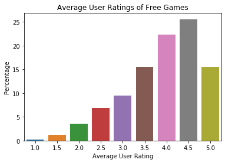

```python
# Creates a bar graph of average user rating frequencies of free games, as a ratio
sns.barplot(x='AverageUserRating', y='FreeGames', data=ratings)

# Creates a title, x, and y labels
plt.title('Average User Ratings of Free Games')
plt.xlabel('Average User Rating')
plt.ylabel('Percentage')

# Displays the plot
plt.show()
```

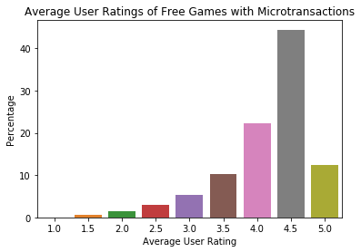

```python
# Creates a bar graph of average user rating frequencies of free games with microtransactions, as a ratio
sns.barplot(x='AverageUserRating', y='FreeandMicro', data=ratings)

# Creates a title, x, and y labels
plt.title('Average User Ratings of Free Games with Microtransactions')
plt.xlabel('Average User Rating')
plt.ylabel('Percentage')

# Displays the plot
plt.show()
```

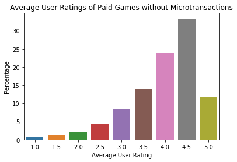

```python
# Creates a bar graph of average user rating frequencies of paid games without microtransactions, as a ratio
sns.barplot(x='AverageUserRating', y='PaidGames', data=ratings)

# Creates a title, x, and y labels
plt.title('Average User Ratings of Paid Games without Microtransactions')
plt.xlabel('Average User Rating')
plt.ylabel('Percentage')

# Displays the plot
plt.show()
```

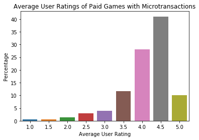

```python
# Creates a bar graph of average user rating frequencies of paid games with microtransactions, as a ratio
sns.barplot(x='AverageUserRating', y='PaidandMicro', data=ratings)

# Creates a title, x, and y labels
plt.title('Average User Ratings of Paid Games with Microtransactions')
plt.xlabel('Average User Rating')
plt.ylabel('Percentage')

# Displays the plot
plt.show()
```

## Analysis of Price Structure and Average User Rating

From the graphs, we can make a few tentative observations: (1) free games have the highest number of 5.0 average user ratings but their overall average was the lowest, (2) games with microtransactions have the higher average user ratings than games without microtransactions.

However, we need to do statistical analysis on this data (in the next step) to verify these observations.

## AgeRating vs. AverageUserRating

```python
age_rating = games.copy(deep=True)

# Drops unnecessary columns
age_rating = age_rating.drop(['Name','UserRatingCount','Price','InAppPurchases','Description','Developer','Languages','PrimaryGenre','Genres'], axis=1)

age_rating = age_rating.groupby('AgeRating', as_index=False).sum()

age_rating
```

|  | AgeRating | AverageUserRating |
| --- | --- | --- |
| 0 | 12+ | 5440.0 |
| 1 | 17+ | 1136.0 |
| 2 | 4+ | 17878.0 |
| 3 | 9+ | 5963.0 |

## Genres vs. AverageUserRating

```python
filtered_genres = games.copy(deep=True)

filtered_genres.Genres = games['Genres'].str.split(',').\
                    apply(lambda x: [s.strip() for s in x if s.strip() != 'Games' and s.strip() != 'Strategy'])

filtered_genres.head()
```

|  | Name | AverageUserRating | UserRatingCount | Price | InAppPurchases | Description | Developer | AgeRating | Languages | PrimaryGenre | Genres |
| --- | --- | --- | --- | --- | --- | --- | --- | --- | --- | --- | --- |
| 0 | Sudoku | 4.0 | 3553.0 | 2.99 | nan | Join over 21,000,000 of our fans and download ... | Mighty Mighty Good Games | 4+ | DA, NL, EN, FI, FR, DE, IT, JA, KO, NB, PL, PT... | Games | [Puzzle] |
| 1 | Reversi | 3.5 | 284.0 | 1.99 | nan | The classic game of Reversi, also known as Oth... | Kiss The Machine | 4+ | EN | Games | [Board] |
| 2 | Morocco | 3.0 | 8376.0 | 0.00 | nan | Play the classic strategy game Othello (also k... | Bayou Games | 4+ | EN | Games | [Board] |
| 3 | Sudoku (Free) | 3.5 | 190394.0 | 0.00 | nan | Top 100 free app for over a year.\nRated "Best... | Mighty Mighty Good Games | 4+ | DA, NL, EN, FI, FR, DE, IT, JA, KO, NB, PL, PT... | Games | [Puzzle] |
| 4 | Senet Deluxe | 3.5 | 28.0 | 2.99 | nan | "Senet Deluxe - The Ancient Game of Life and A... | RoGame Software | 4+ | DA, NL, EN, FR, DE, EL, IT, JA, KO, NO, PT, RU... | Games | [Board, Education] |

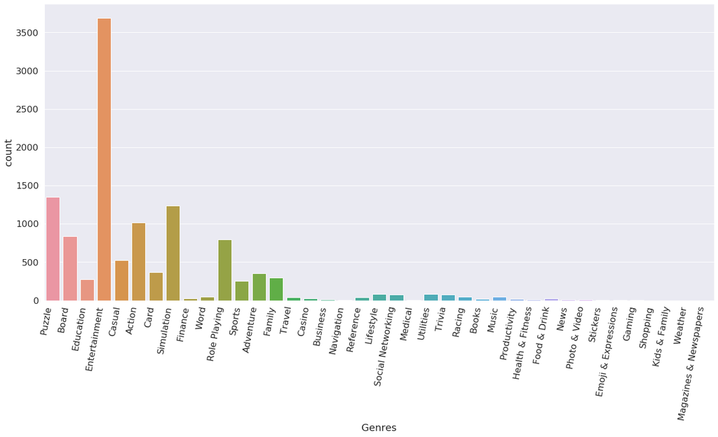

```python
#Setting plot size
plt.figure(figsize=(22, 10))
sns.set(font_scale=1.5)

#Making the data tidy, getting rid of the lists in the Genre column
all_genres = filtered_genres.explode('Genres')


#Getting the min and max values in the UserRatingCount row
min_user = min(all_genres['UserRatingCount'])
max_user = max(all_genres['UserRatingCount'])

testing = all_genres.groupby(['Genres', 'AverageUserRating']).sum()
testing.reset_index(inplace=True)
testing['AUR*URC'] = testing['AverageUserRating'] * testing['UserRatingCount']
testing[testing['Genres'].str.contains('Magazine')]

#all_genres[(all_genres['Genres'].str.contains('Action', na=False)) & (all_genres['AverageUserRating'] == 1.5)]






#this stuff below gets the 3 bar graph p sure

#Creating a bin column so we can also plot the user count easily
all_genres['User Count Bin'] = pd.cut(all_genres['UserRatingCount'],\
                                pd.IntervalIndex.from_tuples([(0, 1000), (1000, 10000), (10000, max_user)]))


# #Plotting genres vs average user rating, and each genre will have 3 bars, showing their average user ranking per user count bin
plot = sns.countplot(x='Genres', data=all_genres)#y='AverageUserRating', data=all_genres)#, #ci=None, hue='User Count Bin')
plot.set_xticklabels(plot.get_xticklabels(), rotation=80, horizontalalignment='right');
```

## Age vs. Average User Rating

```python
games['AgeRating'].unique
```

```
<bound method Series.unique of 0         4+
1         4+
2         4+
3         4+
4         4+
        ...
16950    12+
16956     4+
16962     9+
16967     4+
16993     4+
Name: AgeRating, Length: 7488, dtype: object>
```

```python
age = pd.DataFrame()

age['AgeTest'] = games['AgeRating'].value_counts()
age
#ages: 4+, 9+, 12+, 17+
```

|  | AgeTest |
| --- | --- |
| 4+ | 4424 |
| 9+ | 1456 |
| 12+ | 1321 |
| 17+ | 287 |

```python
age4plus = games.copy(deep=True)
age4plus = age4plus[age4plus.AgeRating == '4+' ]
age4plus = age4plus.drop(['Name','UserRatingCount','Price','InAppPurchases','Description','Developer','Languages','PrimaryGenre','Genres'], axis=1)

age9plus = games.copy(deep=True)
age9plus = age9plus[age9plus.AgeRating == '9+' ]
age9plus = age9plus.drop(['Name','UserRatingCount','Price','InAppPurchases','Description','Developer','Languages','PrimaryGenre','Genres'], axis=1)

age12plus = games.copy(deep=True)
age12plus = age12plus[age12plus.AgeRating == '12+' ]
age12plus = age12plus.drop(['Name','UserRatingCount','Price','InAppPurchases','Description','Developer','Languages','PrimaryGenre','Genres'], axis=1)

age17plus = games.copy(deep=True)
age17plus = age17plus[age17plus.AgeRating == '17+' ]
age17plus = age17plus.drop(['Name','UserRatingCount','Price','InAppPurchases','Description','Developer','Languages','PrimaryGenre','Genres'], axis=1)
```

```python
#age_rating1 = age4plus.groupby('AgeRating', as_index=False).sum()
age9plus.head()
```

|  | AverageUserRating | AgeRating |
| --- | --- | --- |
| 21 | 2.0 | 9+ |
| 26 | 4.0 | 9+ |
| 27 | 3.5 | 9+ |
| 38 | 3.5 | 9+ |
| 40 | 3.5 | 9+ |

```python
rating_age = pd.DataFrame()

rating_age['4+'] = age4plus['AverageUserRating'].value_counts()
rating_age['9+'] = age9plus['AverageUserRating'].value_counts()
rating_age['12+'] = age12plus['AverageUserRating'].value_counts()
rating_age['17+'] = age17plus['AverageUserRating'].value_counts()
```

```python
#age_ratings1 = age_ratings1.drop(['AverageUserRating'])
rating_age.head()
```

|  | 4+ | 9+ | 12+ | 17+ |
| --- | --- | --- | --- | --- |
| 4.5 | 1548 | 620 | 566 | 98.0 |
| 4.0 | 999 | 298 | 340 | 70.0 |
| 5.0 | 647 | 172 | 136 | 29.0 |
| 3.5 | 553 | 184 | 138 | 41.0 |
| 3.0 | 318 | 93 | 75 | 21.0 |

```python
rating_age['AverageUserRating'] = rating_age.index

# Reorders the rows by descending AverageUserRating
rating_age.sort_values('AverageUserRating', axis=0, ascending=False, inplace=True, kind='quicksort')

rating_age['AverageUserRating'] = rating_age.index

# Resets the index
rating_age.reset_index(drop=True, inplace=True)

# Reorders DataFrame columns
rating_age = rating_age[['AverageUserRating','4+','9+','12+','17+']]

rating_age.head()
```

|  | AverageUserRating | 4+ | 9+ | 12+ | 17+ |
| --- | --- | --- | --- | --- | --- |
| 0 | 5.0 | 647 | 172 | 136 | 29.0 |
| 1 | 4.5 | 1548 | 620 | 566 | 98.0 |
| 2 | 4.0 | 999 | 298 | 340 | 70.0 |
| 3 | 3.5 | 553 | 184 | 138 | 41.0 |
| 4 | 3.0 | 318 | 93 | 75 | 21.0 |

```python
rating_age['4+'] = rating_age['4+'] / (len(age4plus)) * 100
rating_age['9+'] = rating_age['9+'] / (len(age9plus)) * 100
rating_age['12+'] = rating_age['12+'] / (len(age12plus)) * 100
rating_age['17+'] = rating_age['17+'] / (len(age17plus)) * 100

rating_age
```

|  | AverageUserRating | 4+ | 9+ | 12+ | 17+ |
| --- | --- | --- | --- | --- | --- |
| 0 | 5.0 | 14.624774 | 11.813187 | 10.295231 | 10.104530 |
| 1 | 4.5 | 34.990958 | 42.582418 | 42.846329 | 34.146341 |
| 2 | 4.0 | 22.581374 | 20.467033 | 25.738077 | 24.390244 |
| 3 | 3.5 | 12.500000 | 12.637363 | 10.446631 | 14.285714 |
| 4 | 3.0 | 7.188065 | 6.387363 | 5.677517 | 7.317073 |
| 5 | 2.5 | 4.633816 | 3.434066 | 3.103709 | 5.923345 |
| 6 | 2.0 | 2.305606 | 2.129121 | 1.059803 | 3.484321 |
| 7 | 1.5 | 1.039783 | 0.412088 | 0.529902 | NaN |
| 8 | 1.0 | 0.135624 | 0.137363 | 0.302801 | 0.348432 |

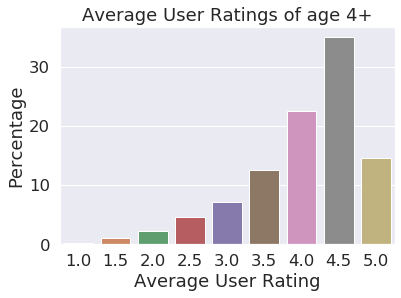

```python
# Creates a bar graph of average user rating frequencies of age over 4, as a ratio
sns.barplot(x='AverageUserRating', y='4+', data=rating_age)

# Creates a title, x, and y labels
plt.title('Average User Ratings of age 4+')
plt.xlabel('Average User Rating')
plt.ylabel('Percentage')

# Displays the plot
plt.show()
```

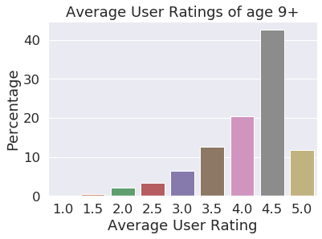

```python
# Creates a bar graph of average user rating frequencies of age over 4, as a ratio
sns.barplot(x='AverageUserRating', y='9+', data=rating_age)

# Creates a title, x, and y labels
plt.title('Average User Ratings of age 9+')
plt.xlabel('Average User Rating')
plt.ylabel('Percentage')

# Displays the plot
plt.show()
```

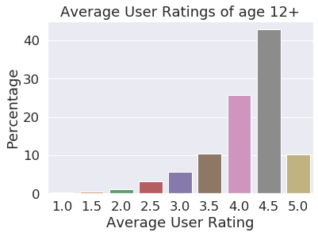

```python
# Creates a bar graph of average user rating frequencies of age over 4, as a ratio
sns.barplot(x='AverageUserRating', y='12+', data=rating_age)

# Creates a title, x, and y labels
plt.title('Average User Ratings of age 12+')
plt.xlabel('Average User Rating')
plt.ylabel('Percentage')

# Displays the plot
plt.show()
```

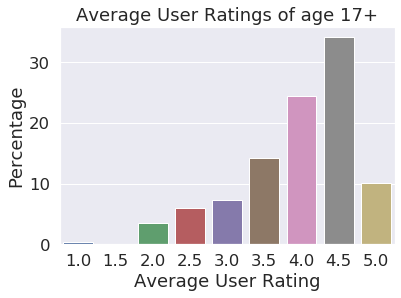

```python
# Creates a bar graph of average user rating frequencies of age over 4, as a ratio
sns.barplot(x='AverageUserRating', y='17+', data=rating_age)

# Creates a title, x, and y labels
plt.title('Average User Ratings of age 17+')
plt.xlabel('Average User Rating')
plt.ylabel('Percentage')

# Displays the plot
plt.show()
```

# 5. Analysis, Hypothesis Testing, and Machine Learning

This step of the data life cycle where we apply modeling techniques to obtain predictive values for our data. In this tutorial, we will apply linear regression, but there are many other regression models available. Further reading material is available on [Towards Data Science](https://towardsdatascience.com/selecting-the-best-machine-learning-algorithm-for-your-regression-problem-20c330bad4ef), [GeeksforGeeks](https://www.geeksforgeeks.org/ml-linear-regression/), and [Medium](https://medium.com/datadriveninvestor/regression-in-machine-learning-296caae933ec).

```python
#Adding the Structure column to our data
ml = games.copy(deep=True)
ml = pd.concat([free_games.assign(Structure='Free'), free_and_microtransactions.assign(Structure='Free w/ Micro'),\
                      paid_games.assign(Structure='Paid'), paid_and_microtransactions.assign(Structure='Paid w/ Micro')]).\
                sort_index()
ml.columns
ml.head()
```

|  | Name | AverageUserRating | UserRatingCount | Price | InAppPurchases | Description | Developer | AgeRating | Languages | PrimaryGenre | Genres | Structure |
| --- | --- | --- | --- | --- | --- | --- | --- | --- | --- | --- | --- | --- |
| 0 | Sudoku | 4.0 | 3553.0 | 2.99 | nan | Join over 21,000,000 of our fans and download ... | Mighty Mighty Good Games | 4+ | DA, NL, EN, FI, FR, DE, IT, JA, KO, NB, PL, PT... | Games | Games, Strategy, Puzzle | Paid |
| 1 | Reversi | 3.5 | 284.0 | 1.99 | nan | The classic game of Reversi, also known as Oth... | Kiss The Machine | 4+ | EN | Games | Games, Strategy, Board | Paid |
| 2 | Morocco | 3.0 | 8376.0 | 0.00 | nan | Play the classic strategy game Othello (also k... | Bayou Games | 4+ | EN | Games | Games, Board, Strategy | Free |
| 3 | Sudoku (Free) | 3.5 | 190394.0 | 0.00 | nan | Top 100 free app for over a year.\nRated "Best... | Mighty Mighty Good Games | 4+ | DA, NL, EN, FI, FR, DE, IT, JA, KO, NB, PL, PT... | Games | Games, Strategy, Puzzle | Free |
| 4 | Senet Deluxe | 3.5 | 28.0 | 2.99 | nan | "Senet Deluxe - The Ancient Game of Life and A... | RoGame Software | 4+ | DA, NL, EN, FR, DE, EL, IT, JA, KO, NO, PT, RU... | Games | Games, Strategy, Board, Education | Paid |

```python
#Dropping the columns unnecessary for regression
dropped_total = ml.drop(['Name', 'UserRatingCount', 'Price', 'InAppPurchases', 'Description', 'Developer', 'Languages',\
               'PrimaryGenre'], axis=1)

#Turning genres into a list of genres not including Games and Strategy because they all have that
dropped_total['Genres'] = dropped_total['Genres'].str.split(',').\
                    apply(lambda x: [s.strip() for s in x if s.strip() != 'Games' and s.strip() != 'Strategy'])

#Making the table tidy
exploded = dropped_total

#Turning Genres and Structure into numerical data using one-hot encoding
test = exploded['Genres'].str.join('|').str.get_dummies()#exploded['Genres'].get_dummies()
exploded = exploded.join(test).drop(['Genres'], axis=1)

dummy = pd.get_dummies(exploded)

#We can drop this structure column because we can determine if an app is free or not from the other structure columns
#We can also drop the AgeRating_4+ column for similar reasons
final = dummy.drop(['Structure_Free', 'AgeRating_4+'], axis=1)


#Getting our models for regression
lin = linear_model.LinearRegression()
rand = ensemble.RandomForestRegressor(n_estimators=100)
state = LinearSVR()
knn = KNeighborsRegressor()

#Using 10-fold cross validation to train our models
scores_lin = model_selection.cross_val_score(lin, final.iloc[:, 1:], final['AverageUserRating'], cv=10)
scores_rand = model_selection.cross_val_score(rand, final.iloc[:, 1:], final['AverageUserRating'], cv=10)
scores_svm = model_selection.cross_val_score(state, final.iloc[:, 1:], final['AverageUserRating'], cv=10)
scores_knn = model_selection.cross_val_score(knn, final.iloc[:, 1:], final['AverageUserRating'], cv=10)

#Printing out the accuracy of our models and the scores
print("Accuracy: %0.2f (+/- %0.2f)" % (scores_lin.mean(), scores_lin.std() * 2))
print("Accuracy: %0.2f (+/- %0.2f)" % (scores_rand.mean(), scores_rand.std() * 2))
print("Accuracy: %0.2f (+/- %0.2f)" % (scores_svm.mean(), scores_svm.std() * 2))
print("Accuracy: %0.2f (+/- %0.2f)" % (scores_knn.mean(), scores_knn.std() * 2))

print(scores_lin)
print(scores_rand)
print(scores_svm)
print(scores_knn)
```

```
Accuracy: -0.05 (+/- 0.27)
Accuracy: -0.11 (+/- 0.30)
Accuracy: -0.23 (+/- 0.52)
Accuracy: -0.57 (+/- 0.26)
[-0.44798643 -0.02953581  0.0012789  -0.01501343  0.00539361  0.01626931
  0.00402535 -0.02200103  0.02412745 -0.07786769]
[-0.53396941 -0.10998025 -0.0515819  -0.07805314 -0.03356366 -0.00941627
 -0.00451457 -0.09285034 -0.01401678 -0.15060123]
[-0.97247052 -0.28790897 -0.22411223 -0.23558026 -0.1520032  -0.08897184
 -0.09523924 -0.05149519 -0.04923279 -0.12073264]
[-0.47278001 -0.42992276 -0.55598127 -0.60352697 -0.54896357 -0.65002655
 -0.40017617 -0.73235811 -0.46489167 -0.83044472]
```

# 6. Insight and Policy Decision

This step of the data life cycle where we utilize our findings to draw conclusions and make inferences.

Turns out, our accuracy given our features is low, so we've ultimately learned which features don't affect the average user rating a lot.

There is still a lot of exploration that can be done on this dataset. App icon colors or designs can be analyzed to see if they can be used as predictors of success. Differences in original release date and current version release date can also be investigated.